# Data Science Project

Data Science Project Aranya Kundu 2023-02-09

```r
# call the necessary libraries
library(dplyr)
```

```r
library(purrr)
library(ggplot2)
library(splitstackshape)
library(forecast)
library(gam)
library(neuralnet)
library(xgboost)
library(cluster)
library(tidyr)
library(knitr)
```

```r
# read all the data files
whr_2013 = read.csv(file = 'D:/Coursework/DS Projects/WHI/World Happiness Report 2013.csv', header = T)
whr_2015 = read.csv(file = 'D:/Coursework/DS Projects/WHI/World Happiness Report 2015.csv', header = T)
whr_2016 = read.csv(file = 'D:/Coursework/DS Projects/WHI/World Happiness Report 2016.csv', header = T)
whr_2017 = read.csv(file = 'D:/Coursework/DS Projects/WHI/World Happiness Report 2017.csv', header = T)
whr_2018 = read.csv(file = 'D:/Coursework/DS Projects/WHI/World Happiness Report 2018.csv', header = T)
whr_2019 = read.csv(file = 'D:/Coursework/DS Projects/WHI/World Happiness Report 2019.csv', header = T)
whr_2020 = read.csv(file = 'D:/Coursework/DS Projects/WHI/World Happiness Report 2020.csv', header = T)
whr_2021 = read.csv(file = 'D:/Coursework/DS Projects/WHI/World Happiness Report 2021.csv', header = T)
whr_2022 = read.csv(file = 'D:/Coursework/DS Projects/WHI/World Happiness Report 2022.csv', header = T)
whr_2023 = read.csv(file = 'D:/Coursework/DS Projects/WHI/World Happiness Report 2023.csv', header = T)
```

#### An alternate way of reading the data files is to read and preprocess the data without disrupting the source data and save the preprocessed data in a rda file.

- We need to do this part of the exercise only once. I did this to remove all missing values from each dataframe and preprocess the data for modeling.

*Caveat:* We already know that the the data for the year 2014 is missing. So, the data frames from numbers 1 - 10 represents data for the years 2013 - 2023 except 2014. and data frame 11 has the combined data for all the years.

```r
file_list = list.files(path = 'D:/Coursework/DS Projects/WHI/', pattern = "*.csv")
df <- vector(mode = 'list', length = length(file_list))
for (i in seq_along(file_list)){
  file_path = file.path('D:/Coursework/DS Projects/WHI/', file_list[i])
  data <- read.csv(file = file_path, header = T)
  # print(dim(data))
  names(data) <- make.names(names(data))
  df[[i]] <- data[, !duplicated(t(data))]
  print(dim(df[[i]]))
}
```

*Note:* It is very important to understand the data in order to preprocess it. + The data has some missing values in each data frame. I have chosen to compute column-wise mean and place the missing values in the respective data frames. This completely makes sense for the given data. Although in some cases, it might be underestimated or overestimated, but overall it will not impact too much. + However, we cannot perform `colMeans` on the whole data frame, because some columns are non-numeric. Luckily for us, the non-numeric columns occur in the 1st two columns and we can compute `colMeans` on the rest of the data frame and do our imputation for the missing data.

Let us code what we mentioned above.

```r
for (i in 1:length(df)){
  missing_count <- rowSums(is.na(df[[i]]))
  rows <- df[[i]][missing_count > 0, ]

  if (nrow(rows) > 0) {
    means <- colMeans(df[[i]][, -c(1, 2)], na.rm = T)
    df[[i]][missing_count > 0, ] <- lapply(df[[i]][missing_count > 0, ], function(x) {
      ifelse(is.na(x), means, x)
    })
  }
}

save(df, file = "WHI.rda") # save the preprocessed data in a rda file
```

#### Now we can load the data from the saved rda file without disturbing the original data and not requiring to preprocess everytime we run it. Also, we have to load the data. This part is boring, but we have to do it once.

```r
load('WHI.rda')

whr_2013 <- df[[1]]
whr_2015 <- df[[2]]
whr_2016 <- df[[3]]
whr_2017 <- df[[4]]
whr_2018 <- df[[5]]
whr_2019 <- df[[6]]
whr_2020 <- df[[7]]
whr_2021 <- df[[8]]
whr_2022 <- df[[9]]
whr_2023 <- df[[10]]
whr_2013_23 <- df[[11]]
```

```r
# Nothing common among all the data sets: Need to prepare items if we want to do machine learning
lists = list(names(whr_2013), names(whr_2015), names(whr_2016), names(whr_2017), names(whr_2018),
             names(whr_2019), names(whr_2020), names(whr_2021), names(whr_2022), names(whr_2023))
intersection = Reduce(intersect, lists)
```

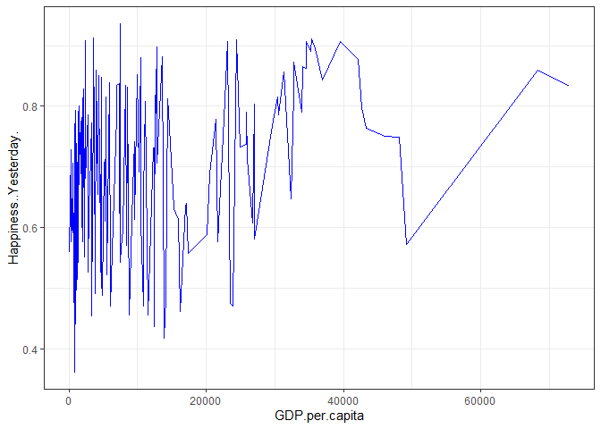

```r
# Data Visualization on 1st data set
plot1 <- ggplot(data = whr_2013, aes(x=GDP.per.capita, y = Happiness..Yesterday.)) +
  geom_line(color="blue") +
  theme_bw() +
  theme(panel.background = element_blank())

plot1 # no visible relationship
```

```r
set.seed(7)
split <- splitstackshape::stratified(whr_2013, group = "Generosity", size = 0.30, bothSets = T)
train_data <- split[[2]]
test_data <- split[[1]]
```

```r
linear_model <- lm(formula = Happiness..Yesterday. ~ Ladder + Social.Support + Corruption + Freedom + Donation + GDP.per.capita + Healthy.life.expectancy, data = train_data)

preds <- predict(linear_model, newdata = test_data)
accuracy(preds, test_data$Happiness..Yesterday.)
```

```
##                    ME      RMSE       MAE      MPE     MAPE
## Test set -0.002648916 0.1379451 0.1059918 -4.13514 17.11837
```

```r
summary(linear_model)
```

```
##
## Call:
## lm(formula = Happiness..Yesterday. ~ Ladder + Social.Support +
##     Corruption + Freedom + Donation + GDP.per.capita + Healthy.life.expectancy,
##     data = train_data)
##
## Residuals:
##       Min        1Q    Median        3Q       Max
## -0.246170 -0.075364  0.009781  0.063684  0.161598
##
## Coefficients:
##                           Estimate Std. Error t value Pr(>|t|)
## (Intercept)              2.047e-01  9.400e-02   2.177 0.031319 *
## Ladder                   5.079e-02  1.503e-02   3.378 0.000971 ***
## Social.Support           1.268e-03  1.073e-01   0.012 0.990593
## Corruption               5.226e-02  5.684e-02   0.919 0.359670
## Freedom                  3.695e-01  7.880e-02   4.689 7.01e-06 ***
## Donation                 2.761e-01  5.680e-02   4.861 3.41e-06 ***
## GDP.per.capita          -2.145e-06  1.014e-06  -2.117 0.036257 *
## Healthy.life.expectancy -2.410e-03  1.252e-03  -1.925 0.056536 .
## ---
## Signif. codes:  0 '***' 0.001 '**' 0.01 '*' 0.05 '.' 0.1 ' ' 1
##
## Residual standard error: 0.0939 on 126 degrees of freedom
## Multiple R-squared:  0.5317, Adjusted R-squared:  0.5057
## F-statistic: 20.44 on 7 and 126 DF,  p-value: < 2.2e-16
```

*Insights:* $R^2$ is only 53% and adjusted $R^2$ is lesser at only 50%. The `RMSE` is 0.137 might not be a very good indicator as the target variable values are also very less. The error can be better understood by `MAPE` which is very high at 17%. Let’s try to fit more complicated models to check if the prediction performance improves.

```r
gam_model <- gam(formula = Happiness..Yesterday. ~ s(Ladder, 4) + s(Social.Support, 4) + s(Corruption, 4) +
                   s(Freedom, 4) + s(Donation, 4) + s(GDP.per.capita, 4) + s(Healthy.life.expectancy, 4),
                 data = train_data)
gam_preds <- predict(gam_model, newdata = test_data)
accuracy(gam_preds, test_data$Happiness..Yesterday.)
```

```
##                  ME      RMSE        MAE      MPE     MAPE
## Test set 0.02646488 0.1073828 0.08840426 2.238037 13.62506
```

```r
summary(gam_model)
```

```
##
## Call: gam(formula = Happiness..Yesterday. ~ s(Ladder, 4) + s(Social.Support,
##     4) + s(Corruption, 4) + s(Freedom, 4) + s(Donation, 4) +
##     s(GDP.per.capita, 4) + s(Healthy.life.expectancy, 4), data = train_data)
## Deviance Residuals:
##       Min        1Q    Median        3Q       Max
## -0.206808 -0.050024 -0.003455  0.062336  0.153859
##
## (Dispersion Parameter for gaussian family taken to be 0.0077)
##
##     Null Deviance: 2.3724 on 133 degrees of freedom
## Residual Deviance: 0.8049 on 105.0002 degrees of freedom
## AIC: -245.1237
##
## Number of Local Scoring Iterations: NA
##
## Anova for Parametric Effects
##                                Df  Sum Sq Mean Sq F value    Pr(>F)
## s(Ladder, 4)                    1 0.73223 0.73223 95.5247 < 2.2e-16 ***
## s(Social.Support, 4)            1 0.00122 0.00122  0.1590 0.6909210
## s(Corruption, 4)                1 0.00010 0.00010  0.0127 0.9104776
## s(Freedom, 4)                   1 0.34880 0.34880 45.5034 8.559e-10 ***
## s(Donation, 4)                  1 0.17503 0.17503 22.8340 5.765e-06 ***
## s(GDP.per.capita, 4)            1 0.09263 0.09263 12.0842 0.0007408 ***
## s(Healthy.life.expectancy, 4)   1 0.00003 0.00003  0.0042 0.9485232
## Residuals                     105 0.80487 0.00767
## ---
## Signif. codes:  0 '***' 0.001 '**' 0.01 '*' 0.05 '.' 0.1 ' ' 1
##
## Anova for Nonparametric Effects
##                               Npar Df Npar F   Pr(F)
## (Intercept)
## s(Ladder, 4)                        3 2.0084 0.11728
## s(Social.Support, 4)                3 3.4169 0.02010 *
## s(Corruption, 4)                    3 1.8182 0.14835
## s(Freedom, 4)                       3 0.6256 0.60007
## s(Donation, 4)                      3 0.9588 0.41515
## s(GDP.per.capita, 4)                3 2.7719 0.04518 *
## s(Healthy.life.expectancy, 4)       3 2.9427 0.03646 *
## ---
## Signif. codes:  0 '***' 0.001 '**' 0.01 '*' 0.05 '.' 0.1 ' ' 1
```

*Insights:* * It is clearly evident that `Ladder`, `Donation`, `Freedom`, `GDP per capita` has significant influence on happiness index of a country. Also, `Healthy Life Expectancy` and `Social Support` has decent significance in determining Happiness. * This were the determining factors in the year 2013. The same needs to be checked for the subsequent years also to have an idea how has the determining factors changed over the years. Or which factor has remained of importance over the years. * `General Additive Model (GAM)` has performed better than Simple linear model as the errors have reduced, however the improvement is not extremely significant.

### Let’s try to fit a neural network model first and check if it can improve the accuracy of prediction.

```r
# prepare the data for neural network model
x_train_nn <- model.matrix(~Ladder + Social.Support + Corruption + Freedom + Donation + GDP.per.capita + Healthy.life.expectancy, data = train_data)[, -1]
x_mean <- apply(x_train_nn, 2, mean)
x_sd <- apply(x_train_nn, 2, sd)
x_train_nn <- scale(x_train_nn, center = x_mean, scale = x_sd)
x_train_nn <- cbind.data.frame(train_data$Happiness..Yesterday., x_train_nn)
colnames(x_train_nn)[1] <- "Happiness.Yesterday"

x_test_nn <- model.matrix(~Ladder + Social.Support + Corruption + Freedom + Donation + GDP.per.capita + Healthy.life.expectancy, data = test_data)[, -1]
x_test_nn <- scale(x_test_nn, center = x_mean, scale = x_sd)
```

```r
# Fit the model
set.seed(7)
nn_model <- neuralnet(formula = Happiness.Yesterday ~ ., data = x_train_nn, hidden = c(6))
nn_model$act.fct
```

```
## function (x)
## {
##     1/(1 + exp(-x))
## }
## <bytecode: 0x000001511d848350>
## <environment: 0x000001511d847a58>
## attr(,"type")
## [1] "logistic"
```

```r
plot(nn_model)

# predict and check for accuracy
nn_preds <- predict(nn_model, newdata = x_test_nn)[, 1]
accuracy(nn_preds, test_data$Happiness..Yesterday.)
```

```
##                  ME      RMSE        MAE       MPE     MAPE
## Test set 0.01253094 0.1172764 0.09812421 -0.357374 15.14645
```

**Next steps:** `Neural Network` has not performed any better for the data set. We can now try fitting some ensemble models which are typically better predictors than `simple linear regression` or `General Additive Models`. This is because they additively use decision tree models to reduce the error as they learn from previous versions. In every new decision tree, a regularization parameter is also used, which are controlled by `alpha` and `lambda` hyperparameters.  
The objective function is the sum of squared differences between the actual and predicted values for all samples, plus a regularization term to control model complexity:

$$Objective = Σ(yi - ŷi)^2 + Regularization \ \ Term$$

```r
dtrain <- xgboost::xgb.DMatrix(data = as.matrix(train_data[, -c(1, 11)]), label = train_data$Happiness..Yesterday.)
dtest <- xgboost::xgb.DMatrix(data = as.matrix(test_data[, -c(1, 11)]), label = test_data$Happiness..Yesterday.)
xgboost_model <- xgboost::xgboost(data = dtrain,
                         eta = 0.3,
                         colsample_bytree = 0.5,
                         subsample = 0.5,
                         min_child_weight = 9,
                         max.depth = 2,
                         gamma = 0,

                         verbose = T,
                         print_every_n = 1000,
                         nrounds = 100000,
                         early_stopping_rounds = 20,
                         nthread = 1,

                         objective = "reg:squarederror",
                         eval_metric = "rmse")
```

```
## Will train until train_rmse hasn't improved in 20 rounds.
##
## Stopping. Best iteration:
```

```r
xgboost_preds <- predict(xgboost_model, dtest)
kable(accuracy(xgboost_preds, test_data$Happiness..Yesterday.))
```

|  | ME | RMSE | MAE | MPE | MAPE |
| --- | --- | --- | --- | --- | --- |
| Test set | -0.0086443 | 0.0607915 | 0.0499204 | -3.172011 | 8.848866 |

**Note:** The accuracy for xgboost is clearly better than ordinary linear regression or general additive model. Both `RMSE` and `MAPE` has improved. We can try to improve this further by hyperparameter tuning. First we will try to improve some hyperparameters and then we will look at importance of the feature variables.

```r
eta <- gamma <- seq(0.1, 1, 0.1)
max_depth <- min_child_weight <- seq(2, 16, 2)
colsample_bytree <- subsample <- seq(0.1, 0.9, 0.1)

cv_params <- expand.grid(eta, gamma, max_depth, min_child_weight, colsample_bytree, subsample)
names(cv_params) <- c("eta", "gamma", "max_depth", "min_child_weight", "colsample_bytree", "subsample")

pd_df <- purrr::pmap_dfr(cv_params, function(eta, gamma, max_depth, min_child_weight, colsample_bytree, subsample){
  set.seed(7)
  xgboost_hyp <- xgboost::xgb.cv(data = dtrain, nrounds = 100000,
                        eta = eta, subsample = subsample,
                        colsample_bytree = colsample_bytree,
                        min_child_weight = min_child_weight,
                        max.depth = max_depth,
                        gamma = gamma,
                        verbose = T,
                        nfold = 4,
                        nthread = 1,
                        print_every_n = 1000,
                        early_stopping_rounds = 20,
                        objective = "reg:squarederror",
                        eval_metric = "rmse")

  results <- cbind.data.frame(xgboost_hyp$evaluation_log[, c("iter", "test_rmse_mean")],
             eta = rep(eta, nrow(xgboost_hyp$evaluation_log)),
             max.depth = rep(max_depth, nrow(xgboost_hyp$evaluation_log)),
             min.child.weight = rep(min_child_weight, nrow(xgboost_hyp$evaluation_log)),
             gamma = rep(gamma, nrow(xgboost_hyp$evaluation_log)),
             colsample_bytree = rep(colsample_bytree, nrow(xgboost_hyp$evaluation_log)),
             subsample = rep(subsample, nrow(xgboost_hyp$evaluation_log))
             )


})

save(pd_df, file = "pd_df.rda")
```

**Caution:** This code runs for almost 12 hours. Please try to use the saved `rda` file instead.

```r
load("pd_df.rda")
```

Now, we can use the values of `hyper parameters` for lowest `test_rmse_mean` and try to fit the model.

```r
final_params <- pd_df[which.min(pd_df$test_rmse_mean), ]
best_xg_model <- xgboost(data = dtrain,
                         nrounds = 100000,
                         eta = final_params$eta,
                         subsample = final_params$subsample,
                         colsample_bytree = final_params$colsample_bytree,
                         max.depth = final_params$max.depth,
                         gamma = final_params$gamma,
                         min_child_weight = final_params$min.child.weight,

                         print_every_n = 1000,
                         verbose = T,
                         nthread = 1,
                         early_stopping_rounds = 20,

                         objective = "reg:squarederror",
                         eval_metric = "rmse"
                         )
```

```
## Will train until train_rmse hasn't improved in 20 rounds.
##
## Stopping. Best iteration:
```

```r
xgboost_preds <- predict(best_xg_model, dtest)
kable(accuracy(xgboost_preds, test_data$Happiness..Yesterday.))
```

|  | ME | RMSE | MAE | MPE | MAPE |
| --- | --- | --- | --- | --- | --- |
| Test set | -0.0089825 | 0.0835631 | 0.059756 | -4.327259 | 10.69531 |

#### Now, let us check for other datasets also and check for the most important parameters for happiness in subsequent years.

```r
set.seed(7)
split_whr_2015 <- splitstackshape::stratified(whr_2015, group = "Region", size = 0.3, bothSets = T, replace = F)
whr_2015_train <- split_whr_2015[[2]]
whr_2015_test <- split_whr_2015[[1]]
```

For these models we will straight away go to the complicated models like `GAM` and `XGBoost` and exclude the Neural Network as we know that it was not performing very well and the dataset is similar in nature and size.

```r
whr_2015_gam <- gam(formula = Happiness.Score ~ s(Standard.Error, 4) + s(Economy..GDP.per.Capita., 4) + s(Family, 4) +
                      s(Health..Life.Expectancy., 4) + s(Freedom, 4) + s(Trust..Government.Corruption., 4) +
                      s(Generosity, 4) + s(Dystopia.Residual, 4), data = whr_2015_train)
whr_2015_preds <- predict(whr_2015_gam, newdata = whr_2015_test)
accuracy(whr_2015_preds, whr_2015_test$Happiness.Score)
```

```
##                   ME         RMSE          MAE          MPE       MAPE
## Test set 3.69827e-05 0.0003166137 0.0002686339 0.0008028508 0.00523953
```

**Insights:** Clearly, the Gam model performs extremely well under the given data set. This can most likely because `Happiness Score` is a computed data which is based on some ML based algorithm that uses similar mathematical calculations as `GAM`.

#### Let us look at how the model performs towards predicting happiness index for the other years.

```r
whr_2016$StandardError <- whr_2016$Upper.Confidence.Interval - whr_2016$Lower.Confidence.Interval
set.seed(7)
split_whr_2016 <- splitstackshape::stratified(whr_2016, group = "Region", size = 0.3, bothSets = T)
whr_2016_train <- split_whr_2016[[2]]
whr_2016_test <- split_whr_2016[[1]]
```

```r
whr_2016_gam <- gam(formula = Happiness.Score ~ s(Economy..GDP.per.Capita., 4) +
                      s(Family, 4) + s(Health..Life.Expectancy., 4) + s(Freedom, 4) + s(Generosity, 4) +
                      s(Dystopia.Residual, 4), data = whr_2016_train)

whr_2016_preds <- predict(whr_2016_gam, newdata = whr_2016_test)
accuracy(whr_2016_preds, whr_2016_test$Happiness.Score)
```

```
##                   ME       RMSE        MAE          MPE     MAPE
## Test set 0.001781703 0.08471958 0.06276733 -0.004236537 1.230577
```

#### We can add the Standard Error column to the model which is the difference between the values in the upper and the lower confidence interval.

```r
whr_2016_gam <- gam(formula = Happiness.Score ~ s(StandardError, 4) + s(Economy..GDP.per.Capita., 4) +
                      s(Family, 4) + s(Health..Life.Expectancy., 4) + s(Freedom, 4) + s(Generosity, 4) +
                      s(Dystopia.Residual, 4), data = whr_2016_train)

whr_2016_preds <- predict(whr_2016_gam, newdata = whr_2016_test)
accuracy(whr_2016_preds, whr_2016_test$Happiness.Score)
```

```
##                   ME       RMSE        MAE        MPE     MAPE
## Test set 0.004707856 0.08546781 0.06280901 0.04966961 1.233571
```

#### Finally, we can try to fit the similar models to one of the more recent data sets. Let us fit the machine learning models to the `2023` data set.

```r
set.seed(7)
train_data_indices <- sample(1:dim(whr_2023)[1], 0.8*dim(whr_2023)[1])
train_data_2023 <- whr_2023[train_data_indices, c(1:12)]
test_data_2023 <- whr_2023[-train_data_indices, c(1:12)]
```

```r
whr_2023_gam <- gam(formula = paste0("Ladder.score ~ ",
                                     paste0("s(", setdiff(names(train_data_2023), c("Country.name", "Ladder.score",
                                                    "upperwhisker", "lowerwhisker", "Ladder.score.in.Dystopia")),
                                            ", 4)", collapse = " + ")) %>% as.formula(),
                    data = train_data_2023)

whr_2023_preds <- predict(whr_2023_gam, newdata = test_data_2023)
accuracy(whr_2023_preds, test_data_2023$Ladder.score)
```

```
##                   ME      RMSE       MAE        MPE     MAPE
## Test set 0.004198433 0.4770615 0.3519254 -0.4130285 7.184949
```

A deeper analysis of all the datasets is definitely possible. However, since the nature of the analysis and conclusions will be extremely similar, we can now focus on analyzing the combined data.

This dataset contains rank and happiness index for all years for around 150 countries. We can try to cluster them into different groups based on year.

```r
cluster_data_2013 <- whr_2013_23[whr_2013_23$Year == 2013, ]

fit1 <- kmeans(x = cluster_data_2013[, 2:4], centers = 5, iter.max = 1000, nstart = 25)
cluster1 <- fit1$cluster
summary(as.factor(cluster1))
```

```
##  1  2  3  4  5
##  5 40 40 42 40
```

**Let’s check countries in each cluster. Since I have set number of centers to `5` we can run a loop 5 times to extract the countries.**

```r
for (i in 1:5){
  cat(glue::glue("Cluster {i} countries:"), sep = "\n")
  cat(cluster_data_2013$Country[cluster1 == i], sep = "\n")
  cat("\n")
}
```

```
## Cluster 1 countries:
## Puerto Rico
## Somalia
## Maldives
## Eswatini
## Namibia
##
## Cluster 2 countries:
## Afghanistan
## Comoros
## Sierra Leone
## Congo Brazzaville
## Senegal
## Congo Kinshasa
## Rwanda
## Egypt
## Tanzania
## Tajikistan
## Botswana
## Syria
## Bulgaria
## Burkina Faso
## Burundi
## Chad
## Central African Republic
## Cameroon
## Sri Lanka
## Cambodia
## Sudan
## Togo
## Mali
## Malawi
## Madagascar
## Liberia
## Kenya
## Ethiopia
## North Macedonia
## Niger
## Gabon
## Georgia
```

[output cut: 121 more lines]

```
## Hong Kong
## North Cyprus
## Nicaragua
## Moldova
## Estonia
## Guatemala
## Greece
## Uzbekistan
## Uruguay
## Albania
## Algeria
## Vietnam
## Angola
## Belarus
## Turkmenistan
```

This will show the countries in each cluster. However, we can see that cluster `1` has only 5 countries while all other clusters have around `40` countries. This proably means that the number of cluster = 5 is not an excellent selection of cluster count. We can do a quality check using a silhouette plot.

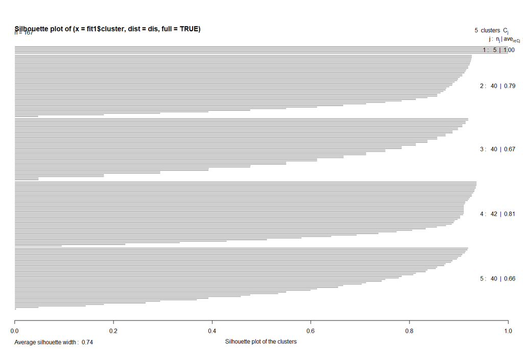

```r
# Calculate distance between samples
dis = dist(cluster_data_2013[2:4])^2
# Set plotting parameters to view plot
op <- par(mfrow= c(1,1), oma= c(0,0, 3, 0),
          mgp= c(1.6,.8,0), mar= .1+c(4,2,2,2))
# Create silhouette for k=5
sil = silhouette (fit1$cluster , # Set clustering
                  dis, # Set distance
                  full = TRUE, # Generate silhouette for all samples

                  )
# Generate silhouette plot
plot(sil, xlab = "Silhouette plot of the clusters")
```

Clearly, cluster 1 has a problem, which is because these 5 countries have exactly same values for Rank and Index,which made it difficult for the algorithm to separate them and they have exact same distances in the silhouette plot also. We can remove these 5 countries and check for fitting a clustering algorithm with 4 centers. Additionally, we can also evaluate to find out the optimum number of clusters for the given dataset.

#### Let us evaluate the optimum number of cluster centers for clustering algorithm for a different year.

```r
set.seed(7)
cluster_data_2015 <- whr_2013_23[whr_2013_23$Year==2015, ]
fit2 <- kmeans(x = cluster_data_2015[, 2:4], centers = 6, iter.max = 1000, nstart = 5)
cluster2 <- fit2$cluster
summary(as.factor(cluster2))
```

```
##  1  2  3  4  5  6
##  5 34 32 32 32 32
```

```r
cluster_data_2015$Country[cluster2==4]
```

```
##  [1] "Turkmenistan"    "Mauritius"       "Hong Kong"       "Vietnam"
##  [5] "China"           "Somaliland"      "Kosovo"          "North Macedonia"
##  [9] "North Cyprus"    "Russia"          "Serbia"          "Cyprus"
## [13] "Morocco"         "Montenegro"      "Mozambique"      "Nigeria"
## [17] "Romania"         "Jamaica"         "Philippines"     "Pakistan"
## [21] "Latvia"          "Bhutan"          "Kyrgyzstan"      "Jordan"
## [25] "Libya"           "Estonia"         "Zambia"          "Azerbaijan"
## [29] "Portugal"        "Algeria"         "Turkiye"         "Indonesia"
```

```r
cluster_data_2015 <- cluster_data_2015[!cluster_data_2015$Country %in% c("Puerto Rico", "Namibia", "South Sudan", "Eswatini", "Gambia"), ]
```

Now that, we have removed the countries let us try to find out the optimal number number of clusters for this data set. We will do this by defining an function.

```r
kmean_cc_no <- function(k){
  cluster <- kmeans(x = cluster_data_2015[, 2:4], centers = k, iter.max = 1000, nstart = 25)
  return (cluster$tot.withinss)
}

# Set maximum cluster number
max_k <-20
# Run algorithm over a range of cluster numbers
wss <- sapply(2:max_k, kmean_cc_no)

# Create a data frame to plot the graph
kmean_wcss <-data.frame(2:max_k, wss)
```

- An alternate method to do the same without using a function is to use the `map_dfr` function from the `purrr` library. The sample code will be as below.

```r
max_k <-20
kmean_wcss <- map_dfr(.x = c(2:max_k), ~{
  cluster <- kmeans(x = cluster_data_2015[, 2:4], centers = .x, iter.max = 1000, nstart = 25)
  elbow <- data.frame(X2.max_k = .x, wss = cluster$tot.withinss)
})
```

We can now try to plot the results to check the optimum `number of clusters`. We can do this by plotting `Within Cluster Sum of Squares` against the `Number of Clusters`.

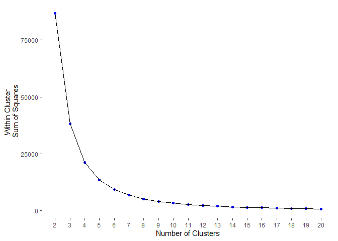

```r
# Plot the graph with ggplot
g_e1 <- ggplot(kmean_wcss, # Set dataset
              aes(x = X2.max_k, y = wss)) + # Set aesthetics
  theme_set(theme_bw(base_size = 22) ) + # Set theme
  geom_point(color = "blue") + # Set geom point for scatter
  geom_line() + # Geom line for a line between points
  scale_x_continuous(breaks = seq(1, 20, by = 1)) + # Set breaks for x-axis
  labs(x = "Number of Clusters", y="Within Cluster \nSum of Squares") + # Set labels
  theme(panel.grid = element_blank(), # Turn of the background grid
        panel.border = element_blank(),
        panel.background = element_blank())
# Generate plot
g_e1
```

**Insights:** The fall has reduced significantly after `6`. We can choose the optimum number of clusters as `6` or `7`. Let us fit a clustering algorithm for 6 cluster centers and try to check the countries in each cluster.

```r
no_of_centers <- 6
best_cluster_2015 <- kmeans(cluster_data_2015[, 2:4], centers = no_of_centers, iter.max = 1000, nstart = 25)
ccno <- best_cluster_2015$cluster

for (i in 1:no_of_centers) {
  cat(glue::glue("Cluster {i} countries: "), sep = "\n")
  cat(cluster_data_2015$Country[ccno == i], sep = "\n")
  cat("\n")
}
```

```
## Cluster 1 countries:
## Haiti
## South Africa
## Mauritania
## Nepal
## Armenia
## Congo Kinshasa
## Georgia
## Ukraine
## Ghana
## Bangladesh
## Sierra Leone
## Myanmar
## India
## Palestine
## Botswana
## Liberia
## Tunisia
## Ethiopia
## Tajikistan
## Zimbabwe
## Kenya
## Malawi
## Sudan
## Iran
## Sri Lanka
## Iraq
## Djibouti
##
## Cluster 2 countries:
## Qatar
## Czechia
## Chile
## South Korea
## Germany
## Uruguay
## Saudi Arabia
## Bahrain
## Uzbekistan
## Argentina
```

[output cut: 118 more lines]

```
## Norway
## Switzerland
## Brazil
## United Kingdom
## Belize
## Austria
## Sweden
## Denmark
## Maldives
## Oman
## Israel
## Luxembourg
## United States
## Belgium
## Ireland
```